# The southern Benguela Current implementation

StrathE2E2

Jack H Laverick Benjamin Grier Kelly Ortega Cisneros Lynne Shannon Douglas C Spiers Michael R Heath

19 Dec 2025

# Introduction

This document describes the configuration of StrathE2E2 for the southern Benguela Current System in South Africa and its parameterisation to enable stationary state fitting for 2010-2070. These represent contrasting periods of environmental conditions.

Volumetric and seabed habitat data define the physical configuration of the system. We regard these as being fixed in time. Similarly, we regard the physiological parameters of the ecology model as being fixed in time. Some of these are set from external data. The remainder are fitted, as detailed here. Changes in the model performance between the different time periods therefore stem from the hydrodynamic, hydro-chemical and fishery driving data. These are detailed in the ecological drivers and fishing fleet sections.

> Department of Mathematics and Statistics, University of Strathclyde, Glasgow, UK.

> E-mail: m.heath@strath.ac.uk

> The code written to support this parameterisation is available on [github](https://github.com/Jack-H-Laverick/MA.SouthAfrica).

# Model Domain

The model domain for the South Africa case study - Southern Benguela extends along the western and southern coastlines of South Africa from the South Africa - Namibia border in the north-west to the Agulhas Bank in the south-east. The eastern extent of the model domain was chosen to encompass the region where the Agulhas current terminates and the Southern Benguela current begins at the Agulhas Bank, marking a distinct change in environmental conditions (Lutjeharms 2006). This region is an important spawning ground for many species that dispers north-westward using the Southern Bengeula current. The Southern Benguela and Agulhas Bank region also differs substantially in fishing activity compared to the eastern coast under the Agulhas current (GFW 2025).

The outer boundary of the offshore zone, and the model domain at 800m deep represents a boundary between distinct fishing activity levels that occurs across the continental shelf gradient (GFW 2025). In consultation with local collaborators, we imposed additional boundaries to limit the extent of the domain between 14.45E and 22.5E, and 28.6S and 36.98S.

[figure not shown]

Figure 1: The spatial structure of StrathE2E; Ocean volumes and seafloor habitats. StrathE2E is built around a simplified spatial structure which represents shelf seas. These spatial units are connected to each other and to boundaries as shown to the right. The volumes connected to each spatial component are highlighted in blue.

## Methodology

Sand, mud and gravel sediment areas were derived from Birch et al. (1986) sediment texture map of the South African coast. As the sediment map is in scanned-pdf format, this was digitised, and combined with rock habitat data from the South African National Biodiversity Institute (SANBI, 2018) using the following methods to create a single spatial dataset.

1. Map image georeferenced using thin-line-splice method (QGIS).
2. Colours corrected ‘GNU Image Manipulation Program’ to create areas of solid colour values and increase contrast between similar colours.
3. Corrected raster map image was polygonised (QGIS).
4. Categories of sediment were simplified to ‘sand’ (contains ‘muddy sand’ and ‘sand’), ‘mud’ (contains ‘sandy mud’, ‘gravelly mud’ and ‘mud’) and ‘gravel’ (contains ‘sandy gravel’, ‘gravel’ and ‘mud-sand-gravel’), and the polygons were cropped to the domain region.
5. SANBI National Biodiversity Assessment habitat classification polygons containing ‘Substratum’ variable with the name ‘Rocky’ were cropped to the domain region.
6. Rocky polygons were overlaid and merged to create a habitat map containing sand, mud, gravel and rock polygons for inshore and offshore zones respectively.

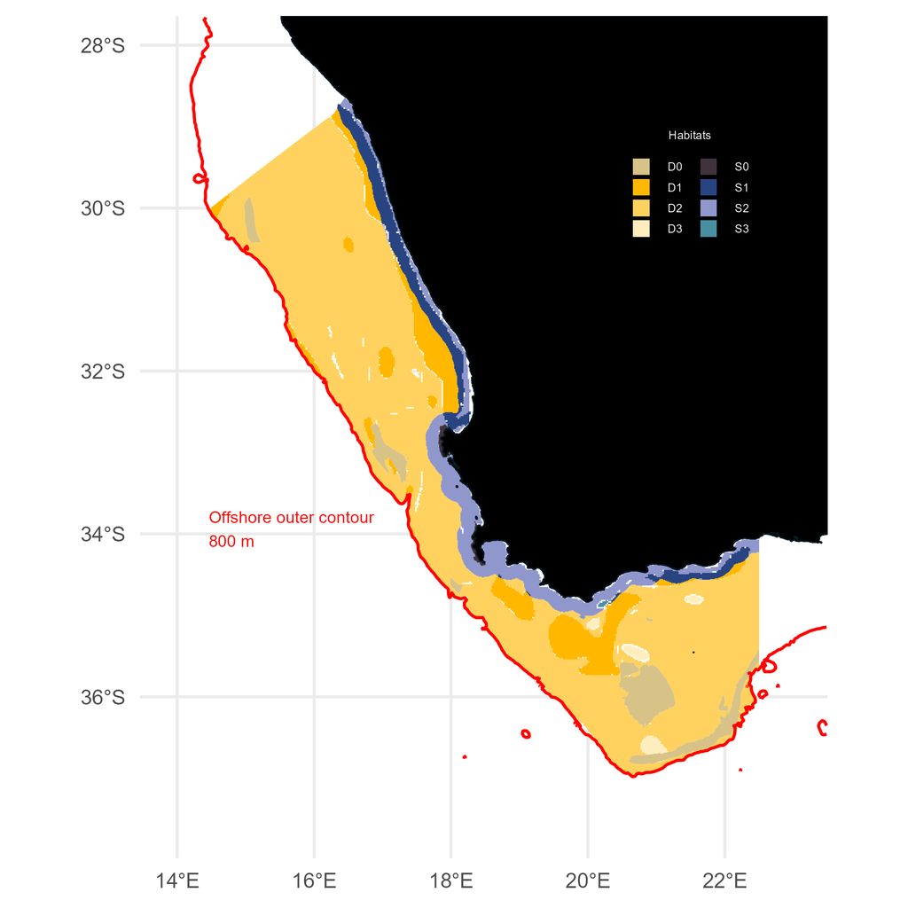

Figure 3: Map of the Southern Benguela model domain. StrathE2E defines seabed sediment habitats as inshore (blues) or offshore (yellows). Within each zone, three sediment classes are represented – fine (muddy, 1), medium (sandy, 2) and coarse (gravel, 3). A fourth class (rock, 0) represents an absence of soft sediment. Sedimentary data are derived from Birch et al. (1986), with the spatial extent of rock sediment derived from SANBI (2018).

# Fixed physical parameterisation

## Background

#### Water column inshore/shallow and offshore/deep zone area proportions and layer thicknesses; seabed habitat area proportions and sediment properties:

#### Parameters for relationship between median grain size, sediment porosity and permeability. Permeability is used as the basis for estimating hydraulic conductivity which is a parameter in the representation of sediment processes in the model:

Porosity (proportion by volume of interstitial water) and permeability of each sediment habitat were derived from median grain sizes using empirically-based relationships.

$$log_{10}(porosity) = p_3 + p_4\left(\frac{1}{1+e^{(\frac{-log_{10}(D_{50})-p_1}{p_2})}}\right)$$
D<sub>50</sub> = median grain size (mm); parameters p<sub>1</sub> = -1.227, p<sub>2</sub> = -0.270, p<sub>3</sub> = -0.436, p<sub>4</sub> = 0.366 (Heath et al. 2015)

$$permeability = 10^{p_5}∙D_{50}^{*p_6}$$

where D<sub>50</sub>* = 0.11 ≤ D<sub>50</sub> ≤ 0.50 p<sub>5</sub> = -9.213, p<sub>6</sub> = 4.615 (M. Heath, Wilson, and Speirs 2015).

These relationships are coded into the StrathE2E2 R-package with the parameters in the csv setup file for the North Sea model. The parameters are probably a reasonable starting point for any future model of a new region. Derivation of the parameters is described in the following text sub-sections.

#### Parameters for in-built relationship between sediment mud content, and slowly degrading (refractory) organic nitrogen content of seabed sediments (see description in this document):

Values for each sediment type derived from parameterised relationships between total organic nitrogen content of sediments (TON%, percent by weight), mud content (mud%, percent by weight) and median grain size (D<sub>50</sub>, mm).

$$mud\% = 10^{p_7}∙𝐷_{50}^{𝑝_8}$$
p<sub>7</sub> = 0.657, p<sub>8</sub> = -0.800

$$TON\% = 10^{𝑝_9}∙mud\%^{𝑝_{10}}$$

p<sub>9</sub> = -1.965, p<sub>10</sub> = 0.590

Proportion of TON estimated to be refractory = 0.9

These relationships are coded into the StrathE2E2 R-package with the parameters in the csv setup file for the North Sea model. The relationships and parameters are probably a reasonable starting point for any future model of a new region, though there are clear regional variations. Derivation of the parameters is described in the following sub-sections.

## Model area proportions

Table 1: Area-proportions of the inshore and offshore zones and the thicknesses of the water column layers. The sea surface area of the model domain is an estimated 184952 km<sup>2</sup>.

| Property | Inshore/shallow | Offshore/deep |
| --- | --- | --- |
| Sea-surface area proportion | 0.1306 | 0.8694 |
| Upper layer thickness (m) | 109.0903 | 50.0000 |
| Lower layer thickness (m) | NA | 226.9523 |

Sediment polygons containing sand, mud, gravel and rock classifications for the inshore and offshore domain regions (Figure 3). The model area proportion was calculated as the proportion of the total domain area occupied by each habitat (e.g. proportion of domain area occupied by s0 inshore-rock habitat), with the sum of all habitat proportions equal to 1. (Table 2).

Table 2: Area proportions and other characteristics of the 8 seabed habitat classes defined in the model by depth, rock or sediment type. The sea surface area of the model domain is an estimated 184952 km<sup>2</sup>. Grain size is the median in mm, Permeability in units of m<sup>2</sup>, nitrogen content in %dw.

| Habitat | Sediment | Area Proportion | Grain size | Porosity | Permeability | Nitrogen content |
| --- | --- | --- | --- | --- | --- | --- |
| Inshore - Shallow |  |  |  |  |  |  |
| S0 | None (Rock) | 0.0029 | NA | NA | NA | NA |
| S1 | Fine | 0.0473 | 0.0078 | 0.4429 | 0.0000 | 0.2700 |
| S2 | Medium | 0.0800 | 0.3536 | 0.3939 | 0.0000 | 0.0270 |
| S3 | Coarse | 0.0004 | 11.3137 | 0.3785 | 0.0000 | 0.0000 |
| Offshore - Deep |  |  |  |  |  |  |
| D0 | None (Rock) | 0.0532 | NA | NA | NA | NA |
| D1 | Fine | 0.0970 | 0.0078 | 0.4787 | 0.0000 | 0.2700 |
| D2 | Medium | 0.7118 | 0.3536 | 0.3890 | 0.0000 | 0.0270 |
| D3 | Coarse | 0.0075 | 11.3137 | 0.3720 | 0.0000 | 0.0000 |

## Sediment porosity

Log-transformed porosity has been shown to have a sigmoidal relationship with log<sub>10</sub>(median grain size) (D<sub>50</sub>, mm) (Wilson et al. 2018):

$$log_{10}(porosity) = p_3 + p_4\left(\frac{1}{1+e^{(\frac{-log_{10}(D_{50})-p_1}{p_2})}}\right)$$

We use this relationship to calculate porosity for sea bed sediments in the Norwegian Sea (Table 2), using an alternative parameterisation to Wilson (Pace et al. 2021). This alternative set of parameters extends the relationship to fine, muddy sediments (Table 3).

Table 3: The four parameters for the function relating sediment porosity to median grain size. From Pace et al. (in review)

| P1 | P2 | P3 | P4 |
| --- | --- | --- | --- |
| -1.035 | -0.314 | -0.435 | 0.302 |

## Hydraulic conductivity

Hydraulic conductivity (H, m.s<sup>-1</sup>) represents the ease with which fluids flow through the particle grain matrix. The related term ‘permeability’ (m<sup>-2</sup>) is a measure of the connectedness of the fluid filled void spaces between the particle grains. Permeability is a function only of the sediment matrix, whilst conductivity is a function of both the sediment and the permeating fluid, in particular the fluid viscosity and density. Hydraulic conductivity is related to permeability by:

$$H = Permeability∙fluid\;density∙\frac{𝑔}{dynamic\;viscosity}$$

where: seawater density = 1027 kg.m<sup>-3</sup> at salinity 35 and temperature 10°C; seawater dynamic viscosity = 1.48 x 10<sup>-3</sup> kg.m<sup>-1</sup>.s<sup>-1</sup> at salinity 35 and temperature 10°C; g = acceleration due to gravity = 9.8 m.s<sup>-1</sup>

Hence, $H = Permeability · 6.8004·10^6$ (m.s<sup>-1</sup> at salinity 35 and temperature 10°C)

Whole sediment permeability can be related to the proportion of sediment classed as mud (D<sub>50</sub> < 62 μm) (Pace et al. 2021). This relationship was used in the production of the Norwegian Basin model (Table 2).

## Sediment organic nitrogen content

The magnitude of the static (refactory) organic nitrogen detritus pool in each sediment type is a required input to the model. The code includes an option to impute values from empirical relationships between total organic nitrogen (TON) and mud content, and between mud content and median grain size. This relationship has been documented in the North Sea implementation of the temperate StrathE2E2 package (M. R. Heath et al. 2021), and is based on sediment data off northeast Scotland.

# Fixed ecological parameterisation

## Domain-specific guilds

StrathE2E represents guilds including Planktivorous Fish, Demersal Fish, Migratory Fish, Carnivorous Zooplankton, Omnivorous Zooplankton, Carnivorous/Scavenge feeding benthos, Suspension/Deposit feeding benthos and Macrophytes. To parameterise the model implementation for the domain region, biological and fishing parameters should be informed by biological and fishing data from domain-specific species that are representative of these guilds in the domain. Species that were present in fishing data were matched to existing StrathE2E species-guild allocations at the genus level, or species level where possible, and species that were not already allocated to guilds were allocated based on their diet and movement patterns.

## Configuration parameters

### Assimilation efficiencies for each living guild in the model.

Fixed parameters defining the proportion of ingested mass of food that contributes to new body tissue, after subtracting defecation and the metabolic costs of digestion and synthesis (M. R. Heath 2012).

### Biomass loss rates due to temperature-dependent metabolism for each living resource guild.

Proportion of biomass lost to ammonia per day due to non-feeding related metabolism at a given reference temperature. Rates for individual guilds broadly related to typical body mass of representative species. Temperature dependency following a Q<sub>10</sub> function.

### Q<sub>10</sub> values for temperature dependent processes, and the Q<sub>10</sub> reference temperature.

Separate Q10 values for autotrophic uptake of nutrient, heterotrophic feeding, and heterotrophic metabolism based on literature data.

### Light intensity required to saturate autotrophic nutrient uptake.

Light saturation intensity for nutrient uptake cannot be treated as a fitted value since it is confounded with other uptake parameters. Value estimated from survey of laboratory experiments.

### Annual weight specific fecundities of planktivorous and demersal fish guilds and the two benthos guilds in the model (suspension/deposit feeders and carnivore/scavenge feeders).

Guild-level values derived by surveying the literature.

### Harvestable biomass density threshold for each resource guild.

The living resource guilds in the model represent a mixture of harvestable and non-harvestable species, especially the invertebrate guilds. The density threshold parameter sets a limit for the guild biomass below which the harvestable species are assumed to be exhausted. Values set from analysis of trawl, plankton and benthos survey species biomass compositions.

### Minimum inedible biomass of carnivorous zooplankton.

The carnivorous zooplankton guild is a key component of the food web, predated on by all the fish and top-predators. However it represents an extremely diverse range of fauna many of which are not edible in significant quantities by the guild predators, e.g. scyphomedusae. A minimum edible threshold is set to ensure that the guild as a whole cannot be extirpated by predation. The value is a rough estimate of scyphomedusae biomass.

## Event timing parameters

Species used to parameterise guild event timings

| StrathE2E guild | Species |
| --- | --- |
| Planktivorous fish | Anchovy (*Engraulis encrasicolus*) |
| Demersal fish | Cape Hakes (*Merluccius spp.)* |
| Suspension/Deposit feeding benthos | Black and Magellan mussels |
| Carnivorous/Scavenge feeding benthos |  |
| Migratory fish |  |

Event timing parameters summarise the timing of larval influx for each guild and how long larvae remain in the water in the domain. Additionally, the event timing parameter file contains information on migratory fish movement in and out of the domain and the overall domain surface area. Event timing parameters were obtained using a literature review and collaborator contribution from Lynne Shannon and Kelly Ortega-Cisneros, and are included in days since January 1st and days in duration.

### Spawning and recruitment start dates and durations for fish

To summarise event timing information for Planktivorous and Demersal fish guilds, we estimate spawning and recruitment timings for the species that contribute the greatest biomass to the guilds and use these as guild estimates. This summarisation method prevents impossible event timings from occurring when using mean values to summarise guild event timings such as very short duration spawning period and much longer duration recruitment period.

For planktivorous fish the highest contributing species to the guild is Anchovy (Engraulis encrasicolus) according to Shannon et al. (2020) domain biomass estimates. We take spawning and recruitment timing estimates for Anchovy from Mullon et al. (2003) and Hutchings et al. (1998) respectively. Combining these sources we parameterised planktivorous fish event timings as spawning for Anchovy from October (273 days since Jan 1) spanning 90 days, and a recruitment period from April (90 days since Jan 1) spanning 90 days.

For demersal fish, the highest contributing species (or genus) to the guild are Cape Hakes (Merluccius spp.) according to Shannon et al. (2020) domain biomass estimates. We take spawning and recruitment timing estimates for Cape Hakes from Grote et al. (2007) and Grote et al. (2012). Combining these sources we parameterised the demersal fish guild as having a spawning period from June (180 days since Jan 1) spanning 90 days, and a recruitment period 150 days later (330 days since Jan 1) spanning 90 days.

### Spawning and recruitment start dates and durations for benthos guilds

The species with the highest contribution to Carnivorous / Scavenge feeding benthos fisheries in the region is the West Coast Rock Lobster. From personal communication with Lynne Shannon and Kelly Ortega-Cisneros, West Coast Rock Lobster spawn during October and November and larvae are present in the water column across most of the year. To implement this ecological process we set spawning for this guild to start in October (270 days since Jan 1) spanning for 60 days, with a guild recruitment start day of 1 (days since Jan 1), and a duration of 360 days. This means that additional larvae are added to the water column in Summer, and the recruitment of larvae to benthos occurs slowly over the entire year resulting in larvae present in the water column year round.

### Migratory fish event timing

There are an estimated 14 migratory species in the migratory fish guild for the domain, with Yellowfin Tuna remaining in the domain region year-round (pers comms Shannon and Ortega-Cisneros (2025).), therefore we estimate the proportion of migratory fish domain-biomass that remains in the domain year round as 1/14. In addition Tunas and Swordfish have a general domain presence from November to March, thus we parameterise the Immigration of these species as starting in November (300 days since Jan 1), spanning for one month (330 days since Jan 1) and the emmigration of these species from the domain as starting in March (60 days since Jan 1), spanning for one month (90 days since Jan 1). We take the total ocean biomass of migratory fish to be equal to the value from the closest existing implementation (Saint Helena Island), with 5,214,177 tonnes wet weight. We estimate the proportion of migratory fish entering the model domain is 0.1.

# Ecological drivers

Monthly resolution time-varying physical and chemical driving parameters for the model were derived from a variety of sources:

Details of how these data were processed are given below, supported by the [nemomedusR](https://jack-h-laverick.github.io/nemoRsem/) and [MiMeMo.tools](https://jack-h-laverick.github.io/MiMeMo.tools/) packages.

### NEMO-ERSEM ensemble:

Four different NEMO-ERSEM runs were used to parameterise different versions of the Southern Benguela implementation of StrathE2E. These four runs are a 2x2 factorial cross of two future projected scenarios (SSP126 and SSP370) with a historical hindcast from 2015, and forcing by two atmospheric models (CNRM and GFDL). In the following sections model output was processed for a 2010-2019 baseline period, and then decadal projections from 2020-2029 until 2060-2069.

### Vertical mixing coefficients between the model layers:

Vertical diffusivity from the NEMO-ERSEM coupled hydro-geochemical model output was interpolated for each grid cell at the 50m boundary depth between the shallow and deep layers of the offshore zone, and the 800m boundary at the deep sea overhang. These values were summarised as monthly averages into period-specific climatological annual cycles of data for decadal periods for all combinations of SSPs and forcings.

### Monthly averaged temperatures for each water column layer:

Derived by monthly averaging values at grid points within the inshore and vertical layers of the offshore zones from the NEMO-ERSEM coupled hydro-geochemical model output, weighted by grid point volumes. Values were summarised into period-specific climatological annual cycles of data.

### Monthly averaged suspended particulate matter (SPM) concentrations (mg.m<sup>-3</sup>) in the shallow zone and the deep zone upper layer:

Monthly averaged values of inorganic suspended particulate matter in sea water are available from the Globcolour project, starting from September 1997. These data are derived from satellite observations using the algorithm of Gohin (2011). Data were downloaded from the ftp server (ftp://ftp.hermes.acri.fr/GLOB/merged/month/). We summarised these values as zonal statistics for the model domain to acquire a climatological annual cycle of data for the 2010-2019 simulation period only.

### Monthly average light attenuation coefficients for the inshore and offshore surface layers:

Light attenuation in open water was parameterised from a linear relationship between the light attenuation coefficient and suspended particulate matter concentration (SPM) (Devlin et al., 2008).

### Monthly averaged daily integrated irradiance at the sea surface (E.m<sup>-2</sup>.d<sup>-1</sup>):

Derived from HadGEM2-ES model output (Jones et al. 2011) which forces the NEMO-ERSEM model run used throughout our implementation. Monthly mean values were summarised into climatological annual cycles of data for decadal periods and NEMO-ERSEM ensembles.

### Monthly averaged daily atmospheric deposition rates of oxidised and reduced nitrogen onto the sea surface in the shallow and deep zones (mMN.m<sup>-2</sup>.d<sup>-1</sup>):

Sourced from the “histsoc” files for a 1901 - 2021 hindcast as monthly averages (Yang J. 2022), available from [CDS](https://cds.climate.copernicus.eu/cdsapp#!/dataset/10.24381/cds.f17050d7?tab=overview). Monthly values were summarised into climatological annual cycles of monthly oxidised and reduced nitrogen deposition rates extracted for 2010-2019. ISIMIPb Projections for SSP126 and SSP370 were processed in the same way for decadal periods up to and including the 2060s.

### Volume fluxes into the model domain across open sea boundaries, and from the upper layer of the offshore/deep zone into the inshore/shallow zone, expressed as proportions of the receiving layer volume per day:

Monthly averaged daily inflow and outflow volume fluxes derived by integrating daily mean velocities directed perpendicular to transects along the model domain boundary at grid points in each depth layer along transects through outputs from the NEMO-ERSEM coupled hydro-geochemical model output. Monthly averaged daily inflow volume fluxes then divided by the volume of the receiving layer in the model domain to estimate a daily flushing rate.

### Mean concentrations of nitrate, ammonia, phytoplankton and suspended detritus (mMN.m<sup>-3</sup>), in adjacent ocean waters inflowing to the offshore/deep zone upper layer, adjacent ocean waters inflowing to the offshore/deep zone lower layer, and adjacent shelf waters inflowing to the inshore/shallow zone:

NEMO-ERSEM outputs included nitrate, ammonia, phytoplankton and suspended detritus. We calculated the depth-averaged concentrations for pixels within the shallow and deep layers of StrathE2E. We then sampled the pixels using the same transects around the model domain as for sampling volume fluxes. Only transects where water flowed into the model domain were sampled, and the average concentration of inflowing waters for target variables was calculated weighting by the flow rate across a transect and the cross-sectional area represented by a transect (average depth and length). Concentrations were then averaged into climatological annual cycles. The flow weighted averaging of concnetrations was calculated on the 5-day NEMO-ERSEM timestep, before averaging to a monthly climatology of concentrations.

# Fishing fleet

## Background

The key configuration data for the fishing fleet model are the definitions of the gears in terms of their power with respect to each of the harvestable resource guilds, discarding rates, processing-at-sea rates, and their seabed abrasion rates. These can be regarded as static parameters for each gear.

An additional class of static parameters is the scaling coefficients between effort (activity x power) and the harvest ratio generated on each model resource guild. These parameters have to be derived by fitting.

Finally, there are parameters which we can consider as driving data since they would be expected to vary with time. These are the activity rates of each gear, and their spatial distributions across the habitat types.

Our principal data sources for the fishing catch data were obtained from Seas Around Us (SAU) (White R. 2020). Seas Around Us data that matches closest to the model implementation domain is provided under the EEZ label “South Africa Atlantic and Cape”. The area this fisheries data covers encompasses the intersection between the South Africa EEZ and the FAO fishing zone 47. This area is larger than the model implementation domain. To obtain estimated catch for the model domain area, we calculated the proportion of spatial effort occurring within the SAU South Africa Atlantic and Cape region that occurs within the model domain. This gives us a unique scaling for each gear type that is then applied to all raw catch values from SAU. For all gear types these proportion scales are calculated from SANBI data layers, as used to calculate the spatial distribution of fishing activity across the habitat types (WCRL landings are assumed to be obtained from within the model domain as this is the dominant habitat/range of the species (Department of Forestry and Environment DFFE 2023)).

## Regional activity rates, of each gear type

Annual regional activity rates for each gear type were determined primarily through literature, with the Global Fishing Watch database being used in the absence of literature estimates for the purse-seine fleet. Activity levels in seconds are collated for each gear type and converted to s/m^2/d by dividing values by the model domain area and 360 (the number of days per year represented in StrathE2E). The details of activity estimation for each gear type are as follows:

### Midwater trawl

Midwater trawl effort is estimated from Reed et al. Reed J. (2017). Values are provided for the number of trawls occurring annually and the proportion and duration of trawls occurring at day and night. These values are then converted to seconds and scaled by the proportion of total midwater trawl activity occurring within the domain (using spatial data provided by SANBI Sink KJ (2019)).

### Nets including small scale

Net effort is estimated for beach-seine and gillnet gears and combined, small scale net activity data is not available. Activity values for the Western Cape are obtained from Hutchings et al. Hutchings K. (2010) as gillnet fishing days and beach-seine hauls per year. We assume that 1 beach seine haul is performed per day to estimate the number of beach-seine fishing days. We assume that fishers fish for half of these days (12h per day) and convert the activity to seconds.

### Pole and line

Pole and line activity data is obtained from West et al. West W. (2024) as the number of vessels with active rights in South Africa for the 2019-2023 period. The average duration of a fishing trip by this fleet is 14 days (West W. 2024). We assume that boats spend 2 weeks at sea and then 2 weeks on land, resulting in 182 days of fishing per year. We assume that boats spend 12h per day fishing and convert the activity to seconds. The activity is then scaled by the proportion of ‘tuna pole’ activity occurring within the domain (spatial data provided by (Sink KJ 2019)).

### Squid jig

Squid jig activity is obtained from (Cochrane K. L. 2014) as the total number of man-hours occurring in South Africa per year. We convert this to vessel-hours assuming that the average number of crew per vessel is 21 (Cochrane K. L. 2014) and convert vessel hours to seconds. The activity is then scaled by the proportion of squid jig activity occurring within the domain (spatial data provided by (Sink KJ 2019)).

### Longline

Longline activity levels are estimated separately for pelagic and demersal longline fleets and then combined.

Pelagic longline activity values are obtained from Parker et al. Parker D. (2021) as the number of boats in South Africa over the 2010-2019 period. The average trip duration is 14 days, we assume that boats spend 2 weeks at sea and 2 weeks on land, resulting in 182 fishing days per year. We assume that 12h of fishing per day is occurring on pelagic longline vessels. This activity is then converted to seconds and scaled by the proportion of pelagic longline activity occurring within the domain (spatial data provided by (Sink KJ 2019)).

Demersal longline activity values are obtained from (M. 2022) as the number of sets used in the fleet annually. We assume the average number of hooks per set is 14,000 (Nyengera R. 2019) and the number of hooks used per day is 14,995, calculating the total number of demersal longline fishing days per year in the fleet. Demersal longline setting generally begins at 2am with hauling occurring until 8pm (18h fishing time per day) (Nyengera R. 2019). The activity is then converted to seconds and scaled by the proportion of activity occurring within the domain (spatial data for ‘hake longline’ provided by (Sink KJ 2019)).

### Purse seine

Due to a lack of literature sources for purse seine activity levels Global Fishing Watch data is used to estimate annual activity in the domain in hours.

### Demersal trawl

The number of trawling hours by the demersal trawl fleet in South Africa are obtained from (Barry Baker G. 2007). Values available cover the 1996-2004 period but values from 1996-1999 are substantially higher than values from 2000-2004, thus we take values from 2000-2004. The mean annual activity level is then converted to seconds and scaled by the proportion of demersal inshore and offshore trawling occurring within the domain (spatial data provided by SANBI Sink KJ (2019)).

### West Coast Rock Lobster Traps

The number of commercial (offshore) trapping trips conducted by the West Coast Rock Lobster trap fishery (2016-2019) were obtained from (J. 2021). We assume the trips last around 2 days (SAFE 2020) and traps are in the water for 75% of the trip duration (18h/day). The activity level is then converted to seconds. We assume that the West Coast Rock Lobster trapping fleet operates exclusively within the model implementation domain.

### Recreational fishing gear

The number of recreational fishers in the Western Cape region is estimated from (Potts W. M.), with fishing occuring an average of 48 days per year. We assume that recreational fishing trips last 5h and convert the activity to seconds.

### Small scale lines

The number of small scale fishers operating in South Africa is obtained from (Department of Forestry and Environment DFFE 2023), with 85% of fishers targetting linefish (small scale lines). We assume that small scale line fishers fish 5 days per week, removing a month of the year due to inclement conditions (230 days/year). We assume that fishers spend 12h per day fishing. Activity is then converted to seconds and scaled by the proportion of linefishing effort occurring within the model domain area.

### Subsistence fishing gear

The number of subsistence fishers fishing in the model domain is estimated in (Clark B. M. 2002). Subsistence fishing is estimated to occur 219 days per year (Ermgassen Philine S. E. zu 2020). Fisher testimony conveys fishing starting from 4am (Support of Fishworkers ICSF 2023), we assume that the average fishing duration is 12h/day. Activity is then converted to seconds.

## Spatial proportional distribution of activity by each gear

For all fishing fleets, the proportion of fishing gear activity over the habitat domain is calculated as the proportion of the target gear’s activity that occurs within each habitat/shore type. E.g. if 1h of trawling occurs in the inshore rocky habitat type and the total amount of activity occurring in the domain is 10h then the inshore rocky habitat type will have a proportion of 0.1. This produces a gear-type x habitat matrix, with rows for each gear-type summing to 1. Proportion calculations were primarily performed using spatial activity data in raster formats and habitat domain data in vector formats.

Where data are obtained from SANBI, the data have been created to contribute to cumulative marine pressure mapping for the 2018 National Biodiversity Assessment by Stephen Holness (Holness 2018). These data were created from various sources of spatial fishing activity and catch, and have been manipulated to remove outlier values (e.g. removing values above the 90% percentile). As some layers are derived from spatial catch density, these layers may not fully represent the extent of fleet activity. These layers are not considered to be accurrate, but rather a best guess at the distribution of fishing activity across South African waters. It is acknowledged that mapping of small scale and subsistence fishing is preliminary and, “according to many stakeholders incomplete” (pers comms Fairweather P. (2025)). Data were obtained from (Sink KJ 2019) and (Holness 2018).

The sources and processing for each gear type are described below:

- `midwater trawl` : Midwater trawl spatial pressure data were obtained from SANBI (Sink KJ 2019). These data are derived from values of hours of trawling.
- `nets including small scale` : Gillnet and Beach-seine spatial pressure data from SANBI (Sink KJ 2019) were combined. These data are derived from numbers of fishing rights allocated / km^2.
- `pole and line` : Pole and line spatial pressure data (labelled ‘Tuna Pole’) were obtained from SANBI (Sink KJ 2019). These data are derived from catch in kg / km^2.
- `squid jig` : Squid jig spatial pressure data were obtained from SANBI (Sink KJ 2019). These data are derived from values of catch in kg / km^2.
- `longline` : Pelagic and demersal (labelled ‘Hake Longline’) longline data were obtained from SANBI (Sink KJ 2019) and combined additively. Demersal longline data are derived from catch in kg / km^2 and pelagic longline data are derived from effort in hooks / km^2.
- `purse seine` : Purse seine data (labelled ‘Small Pelagic Fishery’) were obtained from SANBI (Sink KJ 2019). It was confirmed that the spatial distribution of SANBI small pelagic fishery data and Global Fishing Watch data (GFW 2025) (used for annual activity estimates) matched closely. SANBI spatial data are derived from catch in kg / km^2.
- `demersal trawl` : Demersal (inshore and offshore) trawl data were obtained from SANBI (Sink KJ 2019). Data are derived from effort in hours of trawling.
- `West Coast Rock Lobster traps` : Commercial West Coast Rock Lobster traps are used in rocky habitats at depths greater than 100m (Department of Forestry and Environment DFFE 2023). We distribute West Coast Rock Lobster trap activity uniformly over rocky habitat regions at depths > 100m before calculating the proportion of this activity between inshore and offshore rocky habitat zones.
- `recreational fishing gear` : Linefishery and shore-based recreational fishing gear spatial pressure data from SANBI (Sink KJ 2019) were combined. The linefishery data layer from SANBI approximately represents recreational boat-based fishing activity (Sink KJ 2019). Linefish spatial pressure data were derived from values in catch kg / km^2, while shore-based recreational fishing spatial pressure data were derived from values in density of fishers / km^2.
- `small scale lines` : The ‘Linefishery’ spatial activity data layer from SANBI (Sink KJ 2019) was assumed to represent the spatial effort distribution for the small scale line fleet. This data layer was derived from catch values in kg / km^2.
- `subsistence fishing gear` : Subsistence fishing gear data (labelled ‘Subsistence Harvest’) were obtained from SANBI (Sink KJ 2019). This data layer is derived from values of fishermen / km^2.

## Catching power and discard rates of each resource guild by each gear:

Due to a lack of publically available official fisheries data and time constraints, Seas Around Us catch data are used to calculate fishing fleet input data for the implementation.

Seas Around Us data were compared to available visualisations and data on species catch from the 2023 Status of Marine Living Resources report from the South Africa Department of Forestry, Fisheries and the Environment (Department of Forestry and Environment DFFE 2023). Seas Around Us data were found to generally represent these catch data closely where available. However, it is acknowledged that Seas Around Us data likely diverges from official data to a greater degree for the species/sectors that are not included in the 2023 report. Seas Around Us include qualitative uncertainty scores for each catch data entry. The scores present in the Seas Around Us data used include NA (unknown/unassessed uncertainty), 1 (+/- 50%, low agreement and low evidence) and 2 (+/- 30%, high agreement and limited evidence, or medium agreement and medium evidence, or low agreement and robust evidence). Most data for this region have a score of 1, with little variation during the 2010-2019 period. It is noted that catch reconstruction for the South Africa region was developed for the 1950-2010 period, and then was subsequently updated for years post-2010 (White R. 2020).

Species in Seas Around Us data that were previously not accounted for in StrathE2E guilds were allocated to guilds based on diet composition and movement information from FishBase. Yellowtail Kingfish (*Seriola lalandi*), previously allocated to planktivorous fish, was allocated to Demersal fish due to it’s predatory ecology and classification in EwE from Shannon et al. L. T. Shannon L. J. Ortega-Cisneros K. (2020).

Gear types in Seas Around Us data were matched to the chosen fleets for the StrathE2E model implementation as follows:

- `midwater trawl` => ‘pelagic trawl’
- `nets including small scale` => ‘bagnets’, ‘cast nets’, ‘small scale gillnets’, ‘small scale encircling nets’, ‘small scale seine nets’, ‘small scale other nets’, ‘gillnets’
- `pole and line` => ‘pole and line’
- `longline` => ‘longline’
- `demersal trawl` => ‘bottom trawl’
- `recreational fishing gear` => ‘recreational fishing gear’
- `small scale lines` => ‘small scale lines’, ‘hand lines’
- `subsistence fishing gear` => ‘subsistence fishing gear’
- `squid jig` => The squid jig fishing fleet was added by taking squid catch from the ‘small scale lines’ gear type and renaming the gear to ‘squid jig’. It is assumed that these catches were obtained by fishers using squid jigs and were collated with other small scale lines fishing methods by Seas Around Us, and should be separated into a separate gear type as squid jigs have high species selectivity compared to other small scale lines using hooks.
- `West Coast Rock Lobster traps` => West Coast Rock Lobsters (*Jasus lalandii*) are primarily caught by ‘unknown class’ in Seas Around Us data. It was assumed that this proportion of the *J lalandii* catch was taken by commercial fishers using traps as *J lalandii* are also caught, in lower levels, by the nets gear type, which likely represents the nearshore netfishery for West Coast Rock Lobster. These ‘unknown class’ catch for *J lalandii* were relabeled as `West Coast Rock Lobster traps` gear type. There is low evidence for bycatch in this fishery (Department of Forestry and Environment DFFE 2023), so only *J lalandii* catch were attributed to this gear type.

### Bycatch of birds

#### Longlines

The numbers of birds caught and examined at port from the pelagic longline fishery (Rollinson D. P. 2017) and demersal longline fishery (Petersen S. L. 2009) were used to calculate bycatch weights for birds by the longline fishing gear type. In the longline fishery in South Africa, permits state that any deceased birds must be returned to port for examination, these values were therefore attributed as landings. Petersen et al. Petersen S. L. (2009) suggest that 40% of birds caught in the longline fishery are not returned to port due to operational reasons. Therefore 40% of the total seabird-longline bycatch weight was attributed to seabird-longline discards.

#### Demersal trawl

Watkins Watkins B. P. (2008) present numbers of birds killed in the demersal trawl fishery. It is assumed that these birds are most often killed during waste dumping and are not returned to port, and therefore have been attributed to the fishery as discards (Watkins B. P. 2008).

### Final processing

1. Landings and discards are scaled by the proportion of gear type activity occuring within the SAU region that occurs within the model domain.
2. Landings and discards for each guild, gear type and year are summed and then averaged across 2010-2019 to obtain annual average catch in tonnes.
3. Additional bycatch of birds from literature sources are added to guild * gear type data.
4. Discard rates (only present for demersal fish x demersal trawl) are calculated as the proportion of annual average discards from annual average catch.
5. Units for catch are converted to g/m^2/day by dividing by 1,000,000, the domain area and 360 (number of days represented in StrathE2E).
6. Power is calculated as catch divided by the activity of each gear type (in s/m^2/day).
7. Guild values are converted to nitrogen units per gram of wet weight.

# Target data

Target data is used for optimisation in the fitting of parameters.

## Biological target data

Biological target data for the region such as production measures, diet composition and Production/Biomass ratios were provided by Lynne Shannon and Kelly Ortega-Cisneros (L. T. Shannon L. J. Ortega-Cisneros K. 2020).

Functional group - StrathE2E guild allocations used to match species groups from (2020) with guilds in StrathE2E for the purpose of calculating biological target data values.

| StrathE2E Guild | EwE functional group |
| --- | --- |
| Suspended detritus | Detritus |
| Macrophytes | Benthic producers |
| Phytoplankton | Phytoplankton 1, Phytoplankton 2 |
| Omnivorous zooplankton | Microzooplankton, Mesozooplankton, Macrozooplankton |
| Carnivorous zooplankton | Gelatinous zooplankton, Chokka Squid |
| Planktivorous fish | Anchovy recruits/spawners, Sardine juveniles/adults, Redeye, Other small pelagics, juvenile Horse Mackerel, Chub Mackerel, Lanternfish, Lightfish |
| Migratory fish | Tuna and swordfish |
| Demersal fish | adult Horse Mackerel, Large Sparids, Medium Sparids, Sciaenids, Yellowtail Kingfish, other linefish, small Merluccius spp., large Merluccius spp., pelagic feeding demersal fish, benthic feeding demers… |
| Pinnipeds | Seals |
| Cetaceans | Cetaceans |
| Birds | African Penguin, Cape Gannet, Cape Cormorant, other Seabirds |
| Suspension/deposit feeding benthos | Macrobenthos |
| Carnivorous/scavenge feeding benthos | West Coast Rock Lobster, South Coast Rock Lobster, Meiobenthos |

These data are derived from an Ecopath with Ecosim model of the Southern Benguela region according to the following methodologies:

### Annual total primary production

Estimated from (L. T. Shannon L. J. Ortega-Cisneros K. 2020) using observations from (Brown P. C. 1991) and revised to account for particulate dissolved organic carbon.

### Gross guild production and P/B ratios

Guild biomass were estimated from biomass and abundance estimates from acoustic and demersal surveys from the Department of Environment, Forestry and Fisheries for planktivorous and demersal fish and chokka squid. Biomass for the groups allocated to the omnivorous/carnivorous zooplankton and benthos guilds were estimated during balancing of the revised Southern Benguela Ecopath model (L. T. Shannon L. J. Ortega-Cisneros K. 2020).

Production values were derived from observations (e.g., (Painting S. J. 1992); (Hucthings L. 1991)) and other modelling studies (e.g., (Jarre-Teichman A. 1998)) for both zooplankton groups. For benthos groups, production estimates were derived from other modelling studies and observations ((Berry P. 1980) for West Coast Rock Lobster). Similarly, for planktivorous and demersal groups, production estimates were derived from observational and modelling studies. Please see Appendix A in Shannon et al. J. A. Shannon L. J. Moloney C. L. (2003) and Supplementary Material from Shannon et al. L. T. Shannon L. J. Ortega-Cisneros K. (2020) for a complete list of references and assumptions associated with these estimates.

### Net production and P/B ratios

Estimated using biomass estimates derived from Shannon et al. (2020) for cetaceans, and from observations for seals and seabirds (e.g. (Kirkman S. 2007); (W. A. J. Crawford R. J. M. Ryan P. G. 1991); (K. J. Crawford R. J. M. Dyer B. M. 2007)). Production estimates from Crawford et al. (1991), Shannon et al. (2003; 2020).

### Annual consumption rates

Annual consumption rates were estimated for consumption of planktivorous fish by fish, demersal fish by fish, omnivorous zooplankton by fish and fish larvae, omnivorous zooplankton by carnivorus zooplankton, benthos by fish, birds, pinnipeds and cetaceans.

These were generated using consumption estimates from observational and modelling studies as well as expert knowledge. See Appendix A in Shannon et al. J. A. Shannon L. J. Moloney C. L. (2003) and Supplementary Material from Shannon et al. L. T. Shannon L. J. Ortega-Cisneros K. (2020) for a detailed of references and assumptions associated with these estimates.

### Diet proportions

Diet proportion values were estimated for proportion of planktivorous fish in diet of birds, demersal fish in diet of birds, planktivorous fish in diet of pinnipeds, demersal fish in diet of pinnipeds, planktivorous fish in diet of cetaceans and demersal fish in diet of cetaceans.

Diet proportions were mostly generated using observational studies for the southern Benguela. A comprehensive list of dietary data for the southern Benguela model can be found in Table A.10 of Shannon et al. J. A. Shannon L. J. Moloney C. L. (2003). Diet data sources were revised in Shannon et al. L. T. Shannon L. J. Ortega-Cisneros K. (2020) to account for the higher taxonomic resolution of several functional groups compared to previous versions of the model. See section 4 of the supplementary material of Shannon et al. L. T. Shannon L. J. Ortega-Cisneros K. (2020) for a list of updated references.

### Fisheries data

Annual fisheries data such as landings of planktivorous fish, demersal fish, migratory fish, benthos, carnivorous zooplankton and macrophytes and bycatch data for birds, seals and cetaceans were estimated from Seas Around Us data from 2010 to 2019.

## Physical target data

### Seasonal nutrient concentrations

Season allocations: seasonal nutrient concentrations were calculated using Nov-Feb as ‘winter’ months and May-Aug as ‘summer’ months to match the Northern Hemisphere development of StrathE2E, despite South Africa’s austral seasons.

Seasonal averaged nitrate concentrations were calculated from World Ocean Atlas 2023 data. Monthly data were obtained from [World Ocean Atlas](https://www.ncei.noaa.gov/products/world-ocean-atlas). For the shallow water volume all 1$\degree$ cells touching the domain containing valid data were extracted from depths between 0 and 50. For the deep water volume all cells touching the offshore domain were extracted from depths between 50 and 800. The volumes of the water layers were calculated as the polygon area multiplied by the average depth of the area from mean sea level.

# Model fitting

## CNRM

First the CNRM-SSP3-7.0 variant is used for model fitting. To begin fitting the ecology component of the StrathE2E model to the target data, we first disabled guild landing and bycatch data and launched a round of simulated annealing (e2e_optimise_eco()), with the target data including primary and guild production estimates, as well as P:B ratios and nitrate concentrations from World Ocean Atlas. This round of fitting did not use the landings/bycatch or dietary consumption or composition target data. After manual tweaking to benthos guild harvesting and uptake parameters, a fit of 0.3 likelihood was reached. To fit the fishing component of the model, the updated model was launched with e2e_optimise_fishing(). After this process, model likelihood reached 0.59, however guild yield curves for Planktivorous fish and Demersal fish suggested these guilds were being underfished with F/Fmsy << 1.

Fisheries data from Sea Around Us indicated that 2010-2019 landings were around 3.6 mMNpergWW per year, and indications of F/Fmsy from the Department of Forestry, Fisheries and the Environment (Department of Forestry and Environment DFFE 2012, 2014, 2016, 2020) suggested that key Planktivorous fish species were being fished at an optimal level (F/Fmsy ~ 1) during this period. Additionally, Planktivorous fish are known to be highly variable across time, with a large spike in biomass from 1995-2008 (Coetzee J. C. 2022). As a result, we hypothesised that Planktivorous Fish Production and P:B parameter estimates from EwE (L. T. Shannon L. J. Ortega-Cisneros K. 2020) may not suitably represent the 2010-2019 time period that our model is based on as this EwE model was parameterised for the 1975-2015 time period, leading to Production and P:B ratios that were not consistent with Planktivorous Fish F/Fmsy and landings estimates for the 2010-2019 period. Under this assumption, Planktivorous Fish annual Production and P:B ratio estimates in the target data were turned off for subsequent fitting rounds.

To ensure that model fisheries landings remain close to the estimated 3.6 mMNpergWW and F/Fmsy remains close to 1 for Planktivorous Fish we performed several rounds of parameter searches based on the updated model, adjusting maxmimum nitrogen uptake and density dependent mortality rates for Planktivorous Fish, as well as adjusting Harvest Ratio scaling parameters. Once suitable Planktivorous Fish landings and yield curve were suitable according to the identified targets, parameters were tuned for Demersal Fish to acheive a F/Fmsy around 1. As with Demersal Fish event timing parameterisation, we assume Cape Hakes are a representative species for the guild, and acknowledge that Demersal Fish likely occupy a range of F/Fmsy levels. For example, DFFE Department of Forestry and Environment DFFE (2012);Department of Forestry and Environment DFFE (2014);Department of Forestry and Environment DFFE (2016);Department of Forestry and Environment DFFE (2020) assess many shark species to be fished at F > Fmsy, while Agulhas Sole are assessed to have F < Fmsy. After tuning Demersal Fish parameters, maximum uptake rates for birds, seals and cetaceans were increased by 7, 5 and 3x respectively to prevent guild extinction. A round of simulated annealing was used to readjust ecological parameters, with standard deviations set to 10% of mean measures for landings target values, and Planktivorous Fish Production and P:B ratio target data turned off. Finally, an additional round of simulated annealing was used to confirm that model likelihood would not increase beyond 0.15. The resulting model underrepresented Carnivorous/Scavenging Benthos landings, so an increase of the HR-scale factor of 150x was applied, increasing model likelihood to 0.5.

| StrathE2E Guild | Species |
| --- | --- |
| Planktivorous Fish | Sardine |
| Planktivorous Fish | Herring |
| Planktivorous Fish | Anchovy |
| Demersal Fish | Cape Hakes |

## GFDL

After CNRM fitting, the GFDL-SSP3-7.0 variant is used for model fitting. The initial conditions and parameters from final fitting of CNRM were used to launch fitting for the GFDL model.

# End

## References

Barry Baker G., Abbott C., Tuck G. N. 2007. “A Global Assessment of the Impact of Fisheries-Related Mortality on Shy and White-Capped Albatroses: Conservation Implications.”

Berry P., Smale M. 1980. “An Estimate of Production and Consumption Rates in the Shiny Lobster Panulirus Homarus on a Shallow Littoral Reef Off the Natal Coast, South Africa.”

Brown P. C., Cochrane K. L., Painting S. J. 1991. “Estimates of Phytoplankton and Bacterial Biomass and Production in the Northern and Southern Benguela Ecosystems.”

Clark B. M., Harris J. M., Hauck M. 2002. “Identification of Subsistence Fishers, Fishing Areas, Resource Use and Activities Along the South African Coast.”

Cochrane K. L., Sauer W., Oliver B. 2014. “An Assessment of the Current Status of the Chokka Squid Fishery in South Africa and an Evaluation of Alternative Allocation Strategies.”

Coetzee J. C., van der lingen C. D., de Moor C. L. 2022. “A Summary of the South African Sardine (and Anchovy) Fishery.”

Crawford R. J. M., Kemper J., Dyer B. M. 2007. “Trends in Numbers of Cape Cormorants (Phalacrocorax Capensis) over a 50-Year Period, 1956-57 to 2006-07.”

Crawford R. J. M., Williams A. J., Ryan P. G. 1991. “Seabird Consumption and Production in the Benguela and Western Agulhas Ecosystems.”

Department of Forestry, Fisheries, and the Environment DFFE. 2012. “Status of the South African Marine Fishery Resources 2012.”

———. 2014. “Status of the South African Marine Fishery Resources 2014.”

———. 2016. “Status of the South African Marine Fishery Resources 2016.”

———. 2020. “Status of the South African Marine Fishery Resources 2020.”

———. 2023. “Status of the South African Marine Fishery Resources 2023.”

Ermgassen Philine S. E. zu, Worthington Thomas A., Mukherjee Nibedita. 2020. “Fishers Who Rely on Mangroves: Modelling and Mapping the Global Intensity of Mangrove-Associated Fisheries.”

GFW, Global Fishing Watch. 2025. “Global Apparent Fishing Effort Dataset.”

Gohin, F. 2011. “Annual Cycles of Chlorophyll-a, Non-Algal Suspended Particulate Matter, and Turbidity Observed from Space and in-Situ in Coastal Waters.” *Ocean Science* 7: 705–32.

Heath, Michael R. 2012. “Ecosystem Limits to Food Web Fluxes and Fisheries Yields in the North Sea Simulated with an End-to-End Food Web Model.” *Progress in Oceanography*, End-to-End Modeling: Toward Comparative Analysis of Marine Ecosystem Organization, 102 (September): 42–66. https://doi.org/10.1016/j.pocean.2012.03.004.

Heath, Michael R., Douglas C. Speirs, Ian Thurlbeck, and Robert J. Wilson. 2021. “StrathE2E2: An r Package for Modelling the Dynamics of Marine Food Webs and Fisheries.” *Methods in Ecology and Evolution* 12 (2): 280–87. https://doi.org/10.1111/2041-210X.13510.

Heath, M., R. Wilson, and Douglas C Speirs. 2015. “Modelling the Whole-Ecosystem Impacts of Trawling. A Study Commissioned by Fisheries Innovation Scotland (FIS).”

Holness, S. 2018. “Spatial Intensity Data for South Africa.”

Hucthings L., Verheye H. M., Pillar S. C. 1991. “Estimates of Standing Stock, Production and Consumption of Meso- and Macrozooplankton in the Benguela Ecosystem.”

Hutchings K., Lambert S. J. 2010. “Catch-and-Effort Estimates for the Gillnet and Beach-Seine Fisheries in the Western Cape, South Africa.”

J., Eggers. 2021. “Quantifying the Ecological and Socio-Economic Implications of a Recover/Collapse of South Africa’s West Coast Rock Lobster Fishery.”

Jarre-Teichman A., Moloney C. L., Shannon L. J. 1998. “Comparing Trophic Flows in the Southern Benguela to Those in Other Upwelling Ecosystems.”

Jones, C. D., J. K. Hughes, N. Bellouin, S. C. Hardiman, G. S. Jones, J. Knight, S. Liddicoat, et al. 2011. “The HadGEM2-ES Implementation of CMIP5 Centennial Simulations.” *Geoscientific Model Development* 4 (3): 543–70. https://doi.org/10.5194/gmd-4-543-2011.

Kirkman S., Meÿer M., Oosthuizen W. 2007. “Making Sense of Censuses and Dealing with Missing Data: Trends in Pup Counts for Cape Fur Seal Arctocephalus Pusillus Pusillus for the Period 1972-2004.”

Laverick, Jack H., Douglas C. Speirs, and Michael R. Heath. 2022. “Synthetic Shelf Sediment Maps for the Greenland Sea and Barents Sea.” *Geoscience Data Journal* 10 (2): 220–30. https://doi.org/10.1002/gdj3.154.

Lutjeharms, J. RE. 2006. *The Agulhas Current*.

M., Bergh. 2022. “Trends in the Spatial Distribution of Hake Long Line Fishing Effort.”

Nyengera R., Angel A. 2019. “Gear Configuration and Use of Floats in the South African Demersal Hake Longline Fishery.”

P., Fairweather T. 2025. “Personal Communications.”

Pace, M. C., D. M. Bailey, D. W. Donnan, B. E. Narayanaswamy, H. J. Smith, D. C. Speirs, W. R. Turrell, and M. R. Heath. 2021. “Modelling Seabed Sediment Physical Properties and Organic Matter Content in the Firth of Clyde.” *Earth System Science Data Discussions* 2021: 1–35. https://doi.org/10.5194/essd-2021-23.

Painting S. J., Probyn T. A., Moloney C. L. 1992. “Microheterotrophic Pathways in the Southern Benguela Upwelling Ecosystem.”

Parker D., Mketsu Q., da Silva C. 2021. “South Africa National Report to the Scientific Committee of the Indian Ocean Tuna Commission, 2021.”

Petersen S. L., Ryan P. G., Honig M. B. 2009. “Seabird Bycatch in the Demersal Longline Fishery Off Southern Africa.”

Potts W. M., Bova C. S. “Understanding the Economic Activity Generated by Recreational Fishing in South Africa Provides Insights on the Role of Recreational Fisheries for Social Development.”

Reed J., Kerwath S. E. 2017. “Analysis of Bycatch in the South African Midwater Trawl Fishery for Horse Mackerel Trachurus Capensis Based on Observer Data.”

Rollinson D. P., Ryan P. G., Wanless R. M. 2017. “Patterns and Trends in Seabird Bycatch in the Pelagic Longline Fishery Off South Africa.”

SAFE, South Africa Fishing Ethically. 2020. “A Journey into the South Coast Rock Lobster Fishery.”

Shannon L. J., Jarre A., Moloney C. L. 2003. “Trophic Flows in the Southern Benguela During the 1980s and 1990s.”

Shannon L. J., Lamont T., Ortega-Cisneros K. 2020. “Exploring Temporal Variability in the Southern Benguela Ecosystem over the Past Four Decades Using a Time-Dynamic Ecosystem Model.”

Sink KJ, Skowno AL, Harris LR. 2019. “South African National Biodiversity Assessment 2018 Technical Report Volume 4: Marine Realm.”

Support of Fishworkers ICSF, International Collective in. 2023. “Small-Scale Fishers in South Africa Struggle to Survive While Facing a Litany of Regulations.”

Watkins B. P., Ryan P. G., Petersen S. L. 2008. “Interactions Between Seabirds and Deep-Water Hake Trawl Gear: An Assessment of Impacts in South African Waters.”

West W., Kerwath S., Mketsu Q. 2024. “South African National Report to the Extended Scientific Committee of the Commission for the Conservation of Southern Bluefin Tuna (CCSBT), 2019-2023.”

White R., Derrick B. 2020. “South Africa: Updated Catch Reconstruction for 2011 - 2018” Updating to 2018 the 1950-2010 Marine Catch Reconstructions of the Sea Around Us: Part I – Africa, Antarctica, Europe and the North Atlantic.

Wilson, R. J., D. C. Speirs, A. Sabatino, and M. R. Heath. 2018. “A Synthetic Map of the North-West European Shelf Sedimentary Environment for Applications in Marine Science.” *Earth System Science Data* 10 (1): 109–30. https://doi.org/10.5194/essd-10-109-2018.

Yang J., Tian H. 2022. “ISIMIP3a n-Deposition Input Data (V1.2).”